# Explicit Timecourse

### Are there ‘patterns’ in strategy development among participants?

Inspired by D’Amario et al 2024 which first showed aiming patterns different from an inverted exponential decay function, we noticed that not all participants develop strategies solely as a step or as an exponential process. We note different patterns as well. Tsay et al. 2024 initially suggested distinct classifications of strategies. We can therefore conduct a kMeans cluster analysis to identify patterns in our own data to determine if phenotypes other than gradual and stepwise exist.

**1) Using scaled Features derived from proposed patterns** Features capture standard deviation (baseline normalized), trial-trial changes, linearity (R^2), smoothness, directional sign flips (learning length normalized), jump_ratio, jump dominance.

```r
getFeatures()
```

Determine which features vary with rotation

```r
kruskalFeatures()
```

[output not shown]

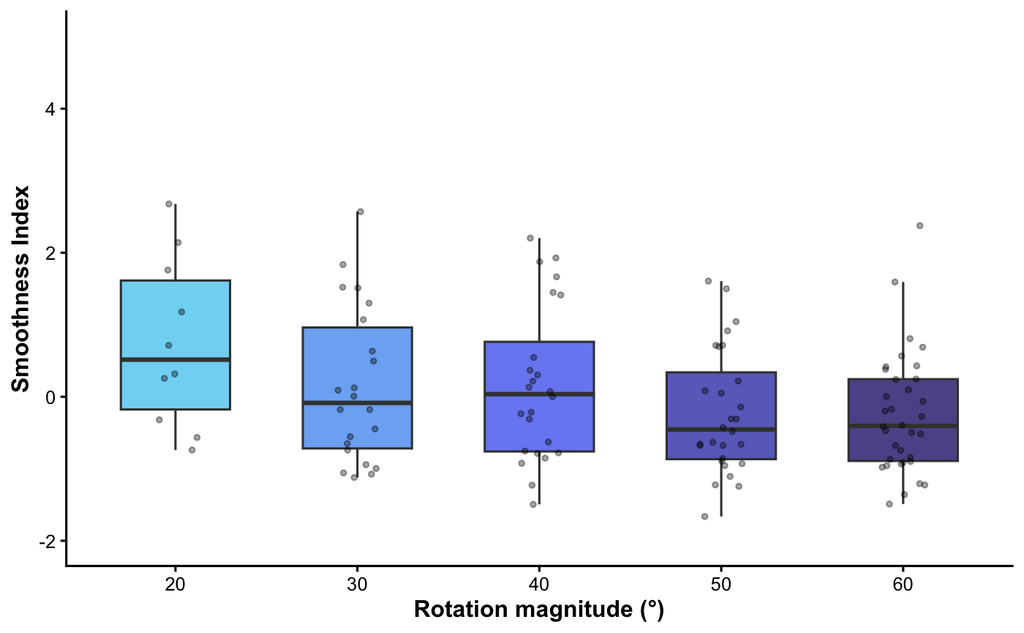

```r
plotBox()
```

**2) Run a PCA on participant z-score features to capture aim heterogeneity**

```r
loadingTable()
```

[output not shown]

**2) Determine which components are most informative** We can create a plot that assesses cumulative variance explained across PC components. Here, we can calculate the variance of each component and divide by the variance sum. Looks like the first 3 components make the largest contribution to the total variance (~80%) with steeper slopes.

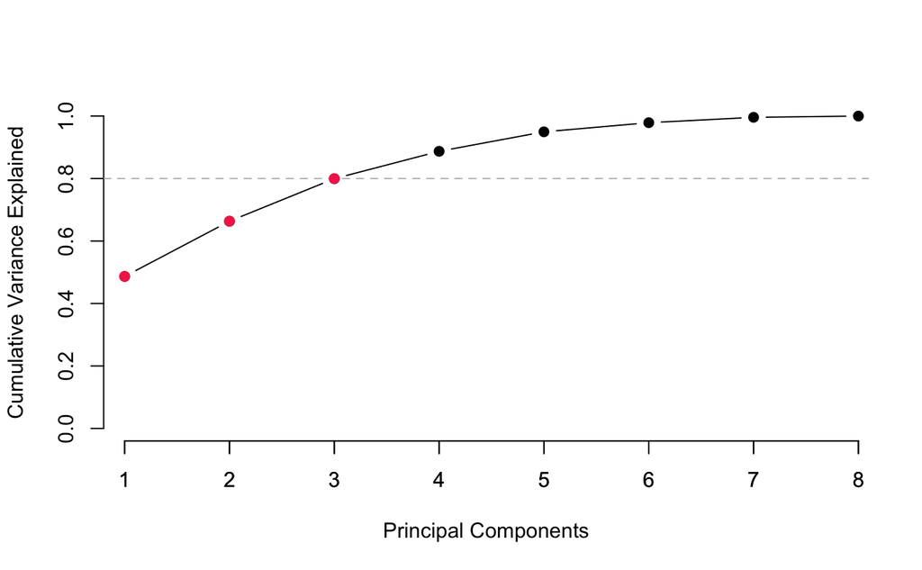

```r
plotScree()
```

**3) Visualize the PCA space**

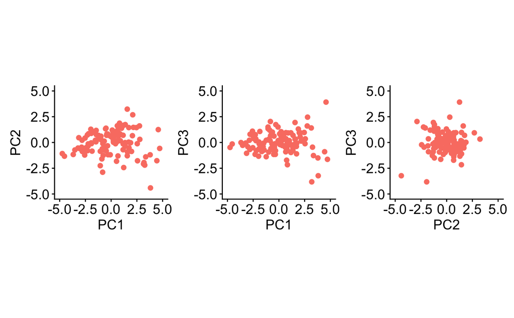

```r
plot_pca_triplot()
```

**4) How does the PCA space vary with rotation**

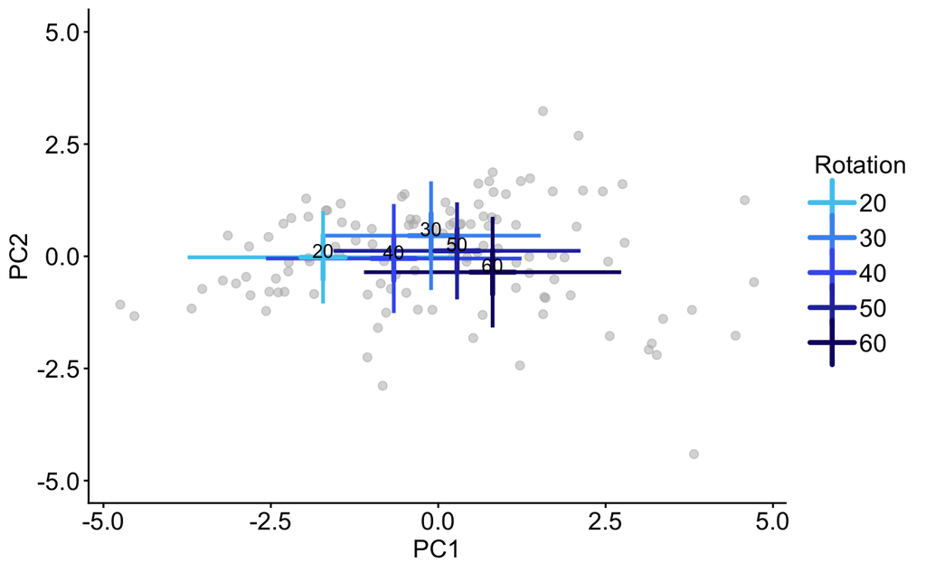

```r
plotRot()
```

60-degree group is far right on PC1 axis, 20 degree group is far left. We can run a linear regression to determine if differences are meaningful

```r
lmRot()
```

[output not shown]

```r
lmPlot()
```

[output not shown]

**5) Run an HCA on most informative components**

Compare clusters to visually predicted clusters

```r
library(dendextend)
dendogram()
```

[output not shown]

```r
pcaPlot()
```

[output not shown]

Note we identify these clusters as partions along a continuum. Because the PCA space is not very separated, this supports the idea that strategy learnin exists along a spectrum. Identified clusters may represent main regions along this spectrum, but we acknowledge the existence of intermediate strategy patterns.

**5) Do identified cluster dsitributions differ across rotation groups?**

```r
stackedPlot()
```

[output not shown]

*Run GLMs* Alternative model = likelihood of strategy * rotation Null Model = likelihood of strategy AICnull - AIcalt = >+, then alternative model is the better fit

likelihood of strategy development (multinomial GLM)

```r
NonAIC()
```

[output not shown]

likelihood of cluster distribution (multinomial GLM)

```r
make_MUmodel()
```

```r
clusters_to_test <- setdiff(unique(proportions_combined$cluster_label), "Non-strategy")
results <- do.call(rbind, lapply(clusters_to_test, make_model))
results
```

```
     cluster       deltaAIC
[1,] "Multi-Step"  "-1.44104797255366"
[2,] "One-Step"    "1.69981529762959"
[3,] "Exploratory" "9.3739760221317"
```

### No cursor reaches

After 120 rotated trials, participants undergo 24 trials of no-cursor reaches. We can use these trials to assess aftereffects and whether it changes across strategy/non-strategy-users and strategy phenotype.

Here, we take the first 8 no cursor trials post rotation to account for all targets. We also baseline normalize from the final nocursor reach trials before the rotation. We should not expect differences in aftereffects (Modchalingam et al., 2019)

####1) Do aftereffects differ across rotation groups?

```r
plotRotAfter()
```

[output not shown]

```r
rotAfterStats()
```

[output not shown]

####2) Do aftereffects differ across strategy vs non strategy?

```r
stratAfterPlot()
```

[output not shown]

```r
stratAfterStats()
```

[output not shown]

####3) Do aftereffects differ across clusters?

```r
clusterAfterPlot()
```

[output not shown]

```r
clusterAfterStats()
```

[output not shown]